# Project

Ann Cannon

3/22/2021

First we read in the training data, change the class of numeric variables from character to numeric, delete the first seven columns (because they won’t help with the model) and eliminate any columns with missing values.

```r
initialData <- read.csv("https://d396qusza40orc.cloudfront.net/predmachlearn/pml-training.csv")

initialData[,c(7:159)] <- sapply(initialData[,c(7:159)], as.numeric)
initialData <- initialData[,c(8:160)]

#Find the variables without missing values
vec <- 0
for(i in 1:153) {
      vec[i] <- sum(is.na(initialData[,i]))
}

noMissing <- initialData[,vec==0]
```

Next we divide the training data set into two parts: a training part and a validation part (called testing here). We also force the classe) variable to be a factor variable.

```r
inTrain <- createDataPartition(y=noMissing$classe, p=.75, list=FALSE)
training <- noMissing[inTrain,]
testing <- noMissing[-inTrain,]

training$classe <- factor(training$classe)
testing$classe <- factor(testing$classe)
```

Finally we begin the model building process by fitting a simple rpart model using all available variables.

```r
modFit <- train(classe~., data=training, method="rpart")
predicts <- predict(modFit, newdata=testing)

confusionMatrix(predicts, testing$classe)
```

```
## Confusion Matrix and Statistics
##
##           Reference
## Prediction    A    B    C    D    E
##          A 1244  400  410  351  120
##          B   25  318   23  152  121
##          C  106  231  422  301  246
##          D    0    0    0    0    0
##          E   20    0    0    0  414
##
## Overall Statistics
##
##                Accuracy : 0.489
##                  95% CI : (0.4749, 0.5031)
##     No Information Rate : 0.2845
##     P-Value [Acc > NIR] : < 2.2e-16
##
##                   Kappa : 0.3326
##
##  Mcnemar's Test P-Value : NA
##
## Statistics by Class:
##
##                      Class: A Class: B Class: C Class: D Class: E
## Sensitivity            0.8918  0.33509  0.49357   0.0000  0.45949
## Specificity            0.6349  0.91884  0.78167   1.0000  0.99500
## Pos Pred Value         0.4927  0.49765  0.32312      NaN  0.95392
## Neg Pred Value         0.9365  0.85205  0.87966   0.8361  0.89105
## Prevalence             0.2845  0.19352  0.17435   0.1639  0.18373
## Detection Rate         0.2537  0.06485  0.08605   0.0000  0.08442
## Detection Prevalence   0.5149  0.13030  0.26631   0.0000  0.08850
## Balanced Accuracy      0.7633  0.62696  0.63762   0.5000  0.72725
```

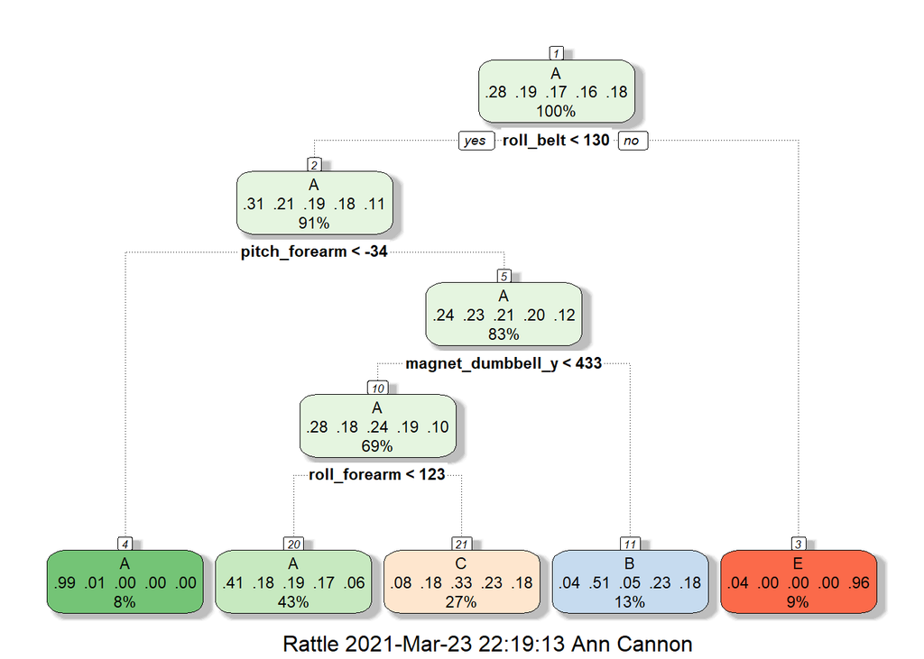

```r
fancyRpartPlot(modFit$finalModel)
```

So we try a model using linear discriminant analysis, using the same variables.

```r
modFitld <- train(classe~., data=training, method="lda")
predlda <- predict(modFitld, newdata=testing)

confusionMatrix(predlda, testing$classe)
```

```
## Confusion Matrix and Statistics
##
##           Reference
## Prediction    A    B    C    D    E
##          A 1087  144   83   47   23
##          B   30  608   73   22  142
##          C  150  120  575  106   84
##          D  121   34  104  598   96
##          E    7   43   20   31  556
##
## Overall Statistics
##
##                Accuracy : 0.6982
##                  95% CI : (0.6851, 0.711)
##     No Information Rate : 0.2845
##     P-Value [Acc > NIR] : < 2.2e-16
##
##                   Kappa : 0.6189
##
##  Mcnemar's Test P-Value : < 2.2e-16
##
## Statistics by Class:
##
##                      Class: A Class: B Class: C Class: D Class: E
## Sensitivity            0.7792   0.6407   0.6725   0.7438   0.6171
## Specificity            0.9154   0.9325   0.8864   0.9134   0.9748
## Pos Pred Value         0.7854   0.6949   0.5556   0.6275   0.8463
## Neg Pred Value         0.9125   0.9154   0.9276   0.9479   0.9188
## Prevalence             0.2845   0.1935   0.1743   0.1639   0.1837
## Detection Rate         0.2217   0.1240   0.1173   0.1219   0.1134
## Detection Prevalence   0.2822   0.1784   0.2111   0.1943   0.1340
## Balanced Accuracy      0.8473   0.7866   0.7795   0.8286   0.7959
```

```r
modFitgbm <- train(classe~., data=training, method="gbm", verbose=FALSE)
predgbm <- predict(modFitgbm, newdata=testing)

confusionMatrix(predgbm, testing$classe)
```

```
## Confusion Matrix and Statistics
##
##           Reference
## Prediction    A    B    C    D    E
##          A 1375   30    0    0    2
##          B    9  888   26    4   10
##          C   10   29  817   27    8
##          D    1    1   11  767    8
##          E    0    1    1    6  873
##
## Overall Statistics
##
##                Accuracy : 0.9625
##                  95% CI : (0.9568, 0.9676)
##     No Information Rate : 0.2845
##     P-Value [Acc > NIR] : < 2.2e-16
##
##                   Kappa : 0.9525
##
##  Mcnemar's Test P-Value : 1.375e-06
##
## Statistics by Class:
##
##                      Class: A Class: B Class: C Class: D Class: E
## Sensitivity            0.9857   0.9357   0.9556   0.9540   0.9689
## Specificity            0.9909   0.9876   0.9817   0.9949   0.9980
## Pos Pred Value         0.9773   0.9477   0.9169   0.9734   0.9909
## Neg Pred Value         0.9943   0.9846   0.9905   0.9910   0.9930
## Prevalence             0.2845   0.1935   0.1743   0.1639   0.1837
## Detection Rate         0.2804   0.1811   0.1666   0.1564   0.1780
## Detection Prevalence   0.2869   0.1911   0.1817   0.1607   0.1796
## Balanced Accuracy      0.9883   0.9617   0.9686   0.9744   0.9835
```

Now we have 96% accuracy which means we have about 4% out of sample error. WE will stay with this model.